# Performance Comparison of Univariate CNN and LSTM Neural Network for Predicting Particulate Matter (PM2.5) Concentration

> By: 05111950010040 - Hafara Firdausi

## 1. Description

### 1.1 Technologies Used

- Python 3.7.3
- Python Libraries :
  - Pandas
  - Numpy
  - Matplotlib
  - Seaborn
  - TensorFlow
  - Scikit-learn
- Others:
  - Visual Studio Code
  - Jupyter Notebook

### 1.2 Dataset

| No. | Attribute | Description |
| --- | --- | --- |
| 1 | No | Row number |
| 2 | Year | Year of data in this row |
| 3 | Month | Month of data in this row |
| 4 | Day | Day of data in this row |
| 5 | Hour | Hour of data in this row |
| 6 | pm2.5 | PM2.5 concentration (ug/m^3) |
| 7 | DEWP | Dew Point (â„ƒ) |
| 8 | TEMP | Temperature (â„ƒ) |
| 9 | PRES | Pressure (hPa) |
| 10 | cbwd | Combined wind direction |
| 11 | Iws | Cumulated wind speed (m/s) |
| 12 | Is | Cumulated hours of snow |
| 13 | Ir | Cumulated hours of rain |

This final project only uses 1 attribute (univariate) which is **pm2.5 concentration** to predict the next pm2.5 concentration.

## 2. Methodology

Initially, the proposed method for predicting PM2.5 concentrations in the air was a CNN-LSTM model proposed by C.-J. Huang and P.-H. Kuo in 2018. It is a model combining the CNN model for feature extraction and the LSTM model for prediction. The detailed architecture of the CNN-LSTM model shown in Figure 1. Also, the flowchart of the prediction system shown in Figure 2. However, CNN-LSTM architecture cannot be implemented yet in this final project.

[figure not shown]

Hence, this final project implements both the univariate CNN model and the univariate LSTM model individually to predict PM2.5 concentration in the air. Then, the performance of the two models compared using MAE (Mean Absolute Error) and RMSE (Root Mean Square Error) metrics.

## 3. Implementation

## 3.1 Preprocessing

First, the raw data must be preprocessed before used for forecasting. In this case, I only fill in the missing value with zero.

```python
# import all libraries needed
import os, sys, math
from datetime import datetime
import pandas as pd
import numpy as np
import matplotlib.pyplot as plt
import seaborn as sns
from sklearn.preprocessing import MinMaxScaler
from sklearn.metrics import mean_squared_error, mean_absolute_error
from tensorflow.keras.models import Sequential
from tensorflow.keras.layers import Dense, LSTM, Dropout, Conv1D, MaxPooling1D, Flatten
from tensorflow.keras.callbacks import EarlyStopping
```

```python
"""
Data Handling
"""
# function to load data
def load_data(path):
    # read all column names
    cols = list(pd.read_csv(path, nrows =1))
    df = pd.read_csv(path, sep=',', header=0, low_memory=False, infer_datetime_format=True, parse_dates={'datetime':['year', 'month', 'day', 'hour']}, date_parser=custom_parser, index_col=['datetime'], usecols=[i for i in cols if i != 'No'])
    # specify new column names
    df.columns = ['pollution', 'dew', 'temp', 'press', 'wnd_dir', 'wnd_spd', 'snow', 'rain']
    return df

# function to export data
def export_data(df, path):
  df.to_csv(path)
  print('>>> data exported succesfully!')

# function to get metadata
def get_metadata(df):
  return {
    'row_num' : df.shape[0],
    'col_num' : df.shape[1],
    'attr' : df.columns.to_list(),
    'timeseries_start': df.index.min(),
    'timeseries_end': df.index.max(),
    'null_value': df.isnull().sum().to_dict(),
    'dtypes': df.dtypes.to_dict()
  }

# function to parse datetime, specifically for this case
def custom_parser(year, month, day, hour):
    date_string = year + ' ' + month + ' ' + day + ' ' + hour
    return datetime.strptime(date_string, '%Y %m %d %H')

# function to print metadata
def print_metadata(metadata):
    print('=====================================')
    print('[ METADATA ]')
    for key, val in metadata.items():
        print('{} => {}'.format(key, val))
    print('=====================================')
```

```python
# define path
PATH = os.getcwd()
DATASET_DIR_PATH = PATH + '/../data/'
DATASET_PATH = {
    'raw': DATASET_DIR_PATH + 'PRSA_data.csv',
    'preprocessed': DATASET_DIR_PATH + 'PRSA_data_preprocessed.csv'
}
```

```python
# get initial data and metadata
df = load_data(DATASET_PATH['raw'])
metadata = get_metadata(df)

df.head(5)
print_metadata(metadata)
```

```
=====================================
[ METADATA ]
row_num => 43824
col_num => 8
attr => ['pollution', 'dew', 'temp', 'press', 'wnd_dir', 'wnd_spd', 'snow', 'rain']
timeseries_start => 2010-01-01 00:00:00
timeseries_end => 2014-12-31 23:00:00
null_value => {'pollution': 2067, 'dew': 0, 'temp': 0, 'press': 0, 'wnd_dir': 0, 'wnd_spd': 0, 'snow': 0, 'rain': 0}
dtypes => {'pollution': dtype('float64'), 'dew': dtype('int64'), 'temp': dtype('float64'), 'press': dtype('float64'), 'wnd_dir': dtype('O'), 'wnd_spd': dtype('float64'), 'snow': dtype('int64'), 'rain': dtype('int64')}
=====================================
```

```python
# get attr that has null value based on the metadata
nullAttr = []
for key, val in metadata['null_value'].items():
    if val > 0:
        nullAttr.append(key)

# fill missing values
for attr in nullAttr:
    df[attr].fillna(0, inplace=True)

# get new metadata
metadata = get_metadata(df)
print_metadata(metadata)
```

```
=====================================
[ METADATA ]
row_num => 43824
col_num => 8
attr => ['pollution', 'dew', 'temp', 'press', 'wnd_dir', 'wnd_spd', 'snow', 'rain']
timeseries_start => 2010-01-01 00:00:00
timeseries_end => 2014-12-31 23:00:00
null_value => {'pollution': 0, 'dew': 0, 'temp': 0, 'press': 0, 'wnd_dir': 0, 'wnd_spd': 0, 'snow': 0, 'rain': 0}
dtypes => {'pollution': dtype('float64'), 'dew': dtype('int64'), 'temp': dtype('float64'), 'press': dtype('float64'), 'wnd_dir': dtype('O'), 'wnd_spd': dtype('float64'), 'snow': dtype('int64'), 'rain': dtype('int64')}
=====================================
```

```python
# drop the first 24 hours or 1 day because the pollution table is 0
df = df[24:]
# get new metadata
metadata = get_metadata(df)
print_metadata(metadata)
```

```
=====================================
[ METADATA ]
row_num => 43800
col_num => 8
attr => ['pollution', 'dew', 'temp', 'press', 'wnd_dir', 'wnd_spd', 'snow', 'rain']
timeseries_start => 2010-01-02 00:00:00
timeseries_end => 2014-12-31 23:00:00
null_value => {'pollution': 0, 'dew': 0, 'temp': 0, 'press': 0, 'wnd_dir': 0, 'wnd_spd': 0, 'snow': 0, 'rain': 0}
dtypes => {'pollution': dtype('float64'), 'dew': dtype('int64'), 'temp': dtype('float64'), 'press': dtype('float64'), 'wnd_dir': dtype('O'), 'wnd_spd': dtype('float64'), 'snow': dtype('int64'), 'rain': dtype('int64')}
=====================================
```

```python
# export data
export_data(df, DATASET_PATH['preprocessed'])
```

```
>>> data exported succesfully!
```

## 3.2 Forecasting

The steps are:

- Preparing
- Splitting
- Training
- Evaluation

### 3.2.1 Preparing

- Convert pandas data frame into an array
- Reshape to adjust the dimension of data
- Normalize data with range 0 to 1

```python
# import the preprocessed data
df_process = pd.read_csv(DATASET_PATH['preprocessed'], header=0, index_col=0)
```

```python
df_process.head()
```

| datetime | pollution | dew | temp | press | wnd_dir | wnd_spd | snow | rain |
| --- | --- | --- | --- | --- | --- | --- | --- | --- |
| 2010-01-02 00:00:00 | 129.0 | -16 | -4.0 | 1020.0 | SE | 1.79 | 0 | 0 |
| 2010-01-02 01:00:00 | 148.0 | -15 | -4.0 | 1020.0 | SE | 2.68 | 0 | 0 |
| 2010-01-02 02:00:00 | 159.0 | -11 | -5.0 | 1021.0 | SE | 3.57 | 0 | 0 |
| 2010-01-02 03:00:00 | 181.0 | -7 | -5.0 | 1022.0 | SE | 5.36 | 1 | 0 |
| 2010-01-02 04:00:00 | 138.0 | -7 | -5.0 | 1022.0 | SE | 6.25 | 2 | 0 |

```python
# save data values as array
val = df_process['pollution'].values
print(val)
print('dimension = {}'.format(val.shape))
```

```
[129. 148. 159. ...  10.   8.  12.]
dimension = (43800,)
```

```python
# reshape to change the dimension of data
val = np.reshape(val, (-1, 1))
print('dimension = {}'.format(val.shape))
```

```
dimension = (43800, 1)
```

```python
# normalize data
scaler = MinMaxScaler(feature_range=(0, 1))
scaled_val = scaler.fit_transform(val)
print(scaled_val)
```

```
[[0.12977867]
 [0.14889336]
 [0.15995976]
 ...
 [0.01006036]
 [0.00804829]
 [0.01207243]]
```

### 3.2.2 Splitting

- Split data into train and test data
- Split data into input and output data

```python
# determine train and test size
# train size = 20%
# test size = 80%

train_size = int(len(val) * 0.20)
test_size = len(val) - train_size
print('Train size: ', train_size)
print('Test size: ', test_size)
```

```
Train size:  8760
Test size:  35040
```

```python
# split data into train and test
data = {
    'train': scaled_val[0:train_size,:],
    'test': scaled_val[train_size:len(scaled_val),:]
}

for key, val in data.items():
    print('{} => {}'.format(key, val))
```

```
train => [[0.12977867]
 [0.14889336]
 [0.15995976]
 ...
 [0.        ]
 [0.        ]
 [0.        ]]
test => [[0.0362173 ]
 [0.03118712]
 [0.02012072]
 ...
 [0.01006036]
 [0.00804829]
 [0.01207243]]
```

```python
# function to split data into input and output
def split_sequence(sequence, n_steps):
    X, y = [], []
    for i in range(len(sequence)):
        # find the end of this pattern
        end_ix = i + n_steps
        # check if we are beyond the sequence
        if end_ix > len(sequence)-1:
            break
        # gather input and output parts of the pattern
        seq_x, seq_y = sequence[i:end_ix, 0], sequence[end_ix, 0]
        X.append(seq_x)
        y.append(seq_y)
    return np.array(X), np.array(y)
```

```python
# split data into input and output
# using the previous 24 hours as input
n_steps = 24

data['train_in'], data['train_out'] = split_sequence(data['train'], n_steps)
data['test_in'], data['test_out'] = split_sequence(data['test'], n_steps)
```

```python
for key, val in data.items():
    print('{} => {}'.format(key, val.shape))
```

```
train => (8760, 1)
test => (35040, 1)
train_in => (8736, 24)
train_out => (8736,)
test_in => (35016, 24)
test_out => (35016,)
```

```python
# data train input
pd.DataFrame(data['train_in']).head()
```

|  | 0 | 1 | 2 | 3 | 4 | 5 | 6 | 7 | 8 | 9 | ... | 14 | 15 | 16 | 17 | 18 | 19 | 20 | 21 | 22 | 23 |
| --- | --- | --- | --- | --- | --- | --- | --- | --- | --- | --- | --- | --- | --- | --- | --- | --- | --- | --- | --- | --- | --- |
| 0 | 0.129779 | 0.148893 | 0.159960 | 0.182093 | 0.138833 | 0.109658 | 0.105634 | 0.124748 | 0.120724 | 0.132797 | ... | 0.158954 | 0.154930 | 0.159960 | 0.164990 | 0.171026 | 0.149899 | 0.154930 | 0.164990 | 0.156942 | 0.126761 |
| 1 | 0.148893 | 0.159960 | 0.182093 | 0.138833 | 0.109658 | 0.105634 | 0.124748 | 0.120724 | 0.132797 | 0.140845 | ... | 0.154930 | 0.159960 | 0.164990 | 0.171026 | 0.149899 | 0.154930 | 0.164990 | 0.156942 | 0.126761 | 0.090543 |
| 2 | 0.159960 | 0.182093 | 0.138833 | 0.109658 | 0.105634 | 0.124748 | 0.120724 | 0.132797 | 0.140845 | 0.152918 | ... | 0.159960 | 0.164990 | 0.171026 | 0.149899 | 0.154930 | 0.164990 | 0.156942 | 0.126761 | 0.090543 | 0.063380 |
| 3 | 0.182093 | 0.138833 | 0.109658 | 0.105634 | 0.124748 | 0.120724 | 0.132797 | 0.140845 | 0.152918 | 0.148893 | ... | 0.164990 | 0.171026 | 0.149899 | 0.154930 | 0.164990 | 0.156942 | 0.126761 | 0.090543 | 0.063380 | 0.065392 |
| 4 | 0.138833 | 0.109658 | 0.105634 | 0.124748 | 0.120724 | 0.132797 | 0.140845 | 0.152918 | 0.148893 | 0.164990 | ... | 0.171026 | 0.149899 | 0.154930 | 0.164990 | 0.156942 | 0.126761 | 0.090543 | 0.063380 | 0.065392 | 0.055332 |

5 rows × 24 columns

```python
# data train output
pd.DataFrame(data['train_out']).head()
```

|  | 0 |
| --- | --- |
| 0 | 0.090543 |
| 1 | 0.063380 |
| 2 | 0.065392 |
| 3 | 0.055332 |
| 4 | 0.065392 |

### 3.2.3 LSTM Model

- 100 neurons LSTM in the first layer
- 1 neuron in the output layer to predict PM2.5 concentration
- Model fitted with training epochs = 50 and batch size = 70

```python
# reshape input menjadi 3D array [samples, time steps, features]
data['train_in'] = np.reshape(data['train_in'], (data['train_in'].shape[0], 1, data['train_in'] .shape[1]))
data['test_in']  = np.reshape(data['test_in'], (data['test_in'].shape[0], 1, data['test_in'].shape[1]))
```

```python
# design model
model = Sequential()
model.add(LSTM(100, input_shape=(data['train_in'].shape[1], data['train_in'].shape[2])))
model.add(Dense(1))
model.compile(loss='mse', optimizer='adam')
```

### 3.2.3.1 Training

```python
# train data and recorded in history
history = model.fit(data['train_in'], data['train_out'], epochs=50, batch_size=70,
                    validation_data=(data['test_in'], data['test_out']), verbose=1, shuffle=False)
```

```
Train on 8736 samples, validate on 35016 samples
```

```python
model.summary()
```

```
Model: "sequential_2"
_________________________________________________________________
Layer (type)                 Output Shape              Param #
=================================================================
lstm_2 (LSTM)                (None, 100)               50000
_________________________________________________________________
dense_2 (Dense)              (None, 1)                 101
=================================================================
Total params: 50,101
Trainable params: 50,101
Non-trainable params: 0
_________________________________________________________________
```

### 3.2.3.2 Evaluating Model

```python
# predicting
prediction = {
    'train_predict': model.predict(data['train_in']),
    'test_predict': model.predict(data['test_in'])
}

# invert prediction
prediction['train_predict'] = scaler.inverse_transform(prediction['train_predict'])
data['train_out'] = scaler.inverse_transform([data['train_out']])
prediction['test_predict'] = scaler.inverse_transform(prediction['test_predict'])
data['test_out'] = scaler.inverse_transform([data['test_out']])
```

```python
# evaluate performance
print('Train MAE:', mean_absolute_error(data['train_out'][0], prediction['train_predict'][:,0]))
print('Train RMSE:',np.sqrt(mean_squared_error(data['train_out'][0], prediction['train_predict'][:,0])))
print('Test MAE:', mean_absolute_error(data['test_out'][0], prediction['test_predict'][:,0]))
print('Test RMSE:',np.sqrt(mean_squared_error(data['test_out'][0], prediction['test_predict'][:,0])))
```

```
Train MAE: 16.506829979319907
Train RMSE: 31.54890737093336
Test MAE: 15.824654052060763
Test RMSE: 28.867913903920243
```

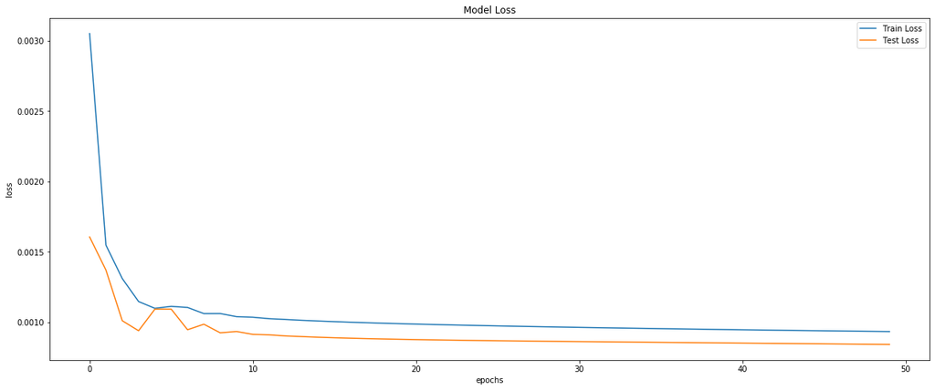

```python
# plotting loss
plt.figure(figsize=(20,8))
plt.plot(history.history['loss'], label='Train Loss')
plt.plot(history.history['val_loss'], label='Test Loss')
plt.title('Model Loss')
plt.ylabel('loss')
plt.xlabel('epochs')
plt.legend(loc='upper right')
plt.show();
```

This kind of graph shows that the model is **a good fit**. A good fit is a case where the performance of the model is good on both the train and validation sets. This can be diagnosed from a plot where the train and validation loss decrease and stabilize around the same point.

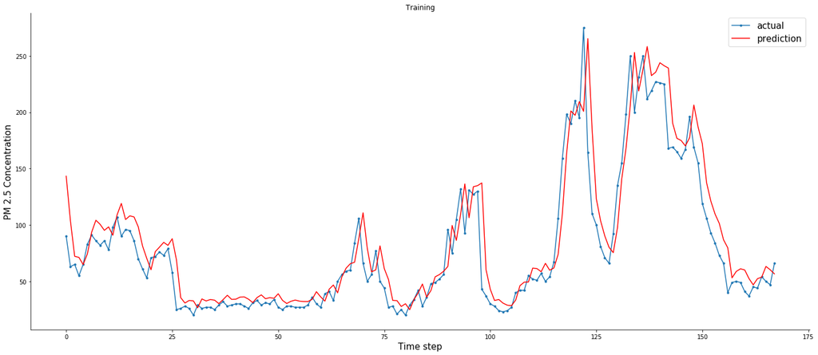

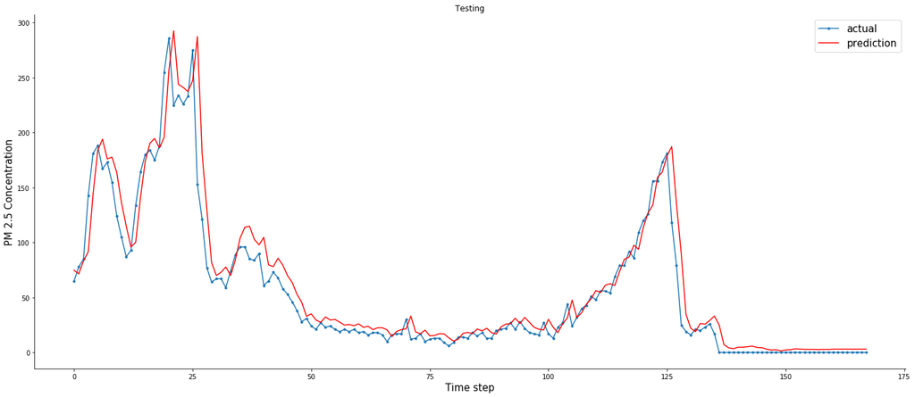

```python
# show actuals and predictions on training and testing data in the first week
rng = 24*7
aa = [x for x in range(rng)]

plt.figure(figsize=(20,8))
plt.plot(aa, data['train_out'][0][:rng], marker='.', label="actual")
plt.plot(aa, prediction['train_predict'][:,0][:rng], 'r', label="prediction")
plt.tight_layout()
sns.despine(top=True)
plt.subplots_adjust(left=0.07)
plt.title('Training')
plt.ylabel('PM 2.5 Concentration', size=15)
plt.xlabel('Time step', size=15)
plt.legend(fontsize=15)
plt.show();

plt.figure(figsize=(20,8))
plt.plot(aa, data['test_out'][0][:rng], marker='.', label="actual")
plt.plot(aa, prediction['test_predict'][:,0][:rng], 'r', label="prediction")
plt.tight_layout()
sns.despine(top=True)
plt.subplots_adjust(left=0.07)
plt.title('Testing')
plt.ylabel('PM 2.5 Concentration', size=15)
plt.xlabel('Time step', size=15)
plt.legend(fontsize=15)
plt.show();
```

### 3.2.4 CNN Model

- Conv1D
- MaxPooling1D
- Flatten
- Dense

```python
# reshape input menjadi 3D array : [samples, time steps, features]
data['train_in'] = np.reshape(data['train_in'], (data['train_in'].shape[0], data['train_in'] .shape[1], 1))
data['test_in']  = np.reshape(data['test_in'], (data['test_in'].shape[0], data['test_in'].shape[1], 1))
```

```python
# design model
model = Sequential()
model.add(Conv1D(filters=64, kernel_size=2, activation='relu', input_shape=(24, 1)))
model.add(MaxPooling1D(pool_size=2))
model.add(Flatten())
model.add(Dense(50, activation='relu'))
model.add(Dense(1))
model.compile(optimizer='adam', loss='mse')
```

### 3.2.4.1 Training

```python
# train data and recorded in history
history = model.fit(data['train_in'], data['train_out'], epochs=50, batch_size=70,
                    validation_data=(data['test_in'], data['test_out']), verbose=1, shuffle=False)
```

```
Train on 8736 samples, validate on 35016 samples
```

```python
model.summary()
```

```
Model: "sequential_3"
_________________________________________________________________
Layer (type)                 Output Shape              Param #
=================================================================
conv1d (Conv1D)              (None, 23, 64)            192
_________________________________________________________________
max_pooling1d (MaxPooling1D) (None, 11, 64)            0
_________________________________________________________________
flatten (Flatten)            (None, 704)               0
_________________________________________________________________
dense_3 (Dense)              (None, 50)                35250
_________________________________________________________________
dense_4 (Dense)              (None, 1)                 51
=================================================================
Total params: 35,493
Trainable params: 35,493
Non-trainable params: 0
_________________________________________________________________
```

### 3.2.4.2 Evaluating Model

```python
# predicting
prediction = {
    'train_predict': model.predict(data['train_in']),
    'test_predict': model.predict(data['test_in'])
}

# invert prediction
prediction['train_predict'] = scaler.inverse_transform(prediction['train_predict'])
data['train_out'] = scaler.inverse_transform([data['train_out']])
prediction['test_predict'] = scaler.inverse_transform(prediction['test_predict'])
data['test_out'] = scaler.inverse_transform([data['test_out']])
```

```python
# evaluate performance
print('Train MAE:', mean_absolute_error(data['train_out'][0], prediction['train_predict'][:,0]))
print('Train RMSE:',np.sqrt(mean_squared_error(data['train_out'][0], prediction['train_predict'][:,0])))
print('Test MAE:', mean_absolute_error(data['test_out'][0], prediction['test_predict'][:,0]))
print('Test RMSE:',np.sqrt(mean_squared_error(data['test_out'][0], prediction['test_predict'][:,0])))
```

```
Train MAE: 22.74579175460517
Train RMSE: 37.475071563818
Test MAE: 22.922563535337922
Test RMSE: 39.04075381532723
```

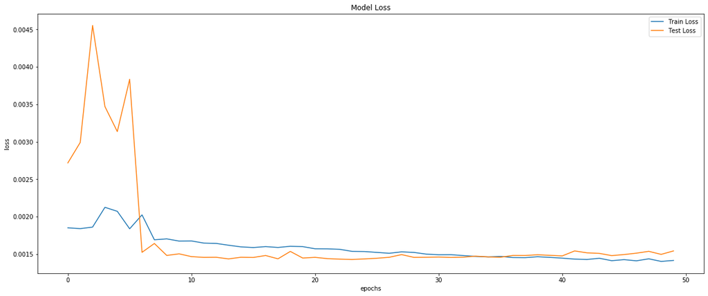

```python
# plotting loss
plt.figure(figsize=(20,8))
plt.plot(history.history['loss'], label='Train Loss')
plt.plot(history.history['val_loss'], label='Test Loss')
plt.title('Model Loss')
plt.ylabel('loss')
plt.xlabel('epochs')
plt.legend(loc='upper right')
plt.show();
```

This kind of graph shows that the model is **an overfit**. An overfit model is one where performance on the train set is good and continues to improve, whereas performance on the validation set improves to a point and then begins to degrade. This can be diagnosed from a plot where the train loss slopes down and the validation loss slopes down, hits an inflection point, and starts to slope up again.

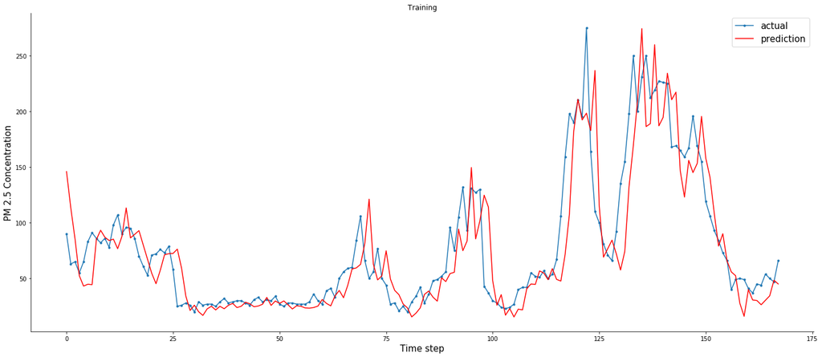

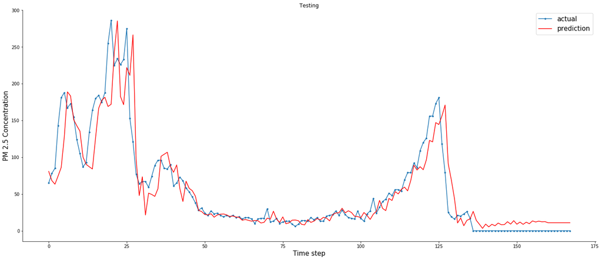

```python
# show actuals and predictions on training and testing data in the first week
rng = 24*7
aa = [x for x in range(rng)]

plt.figure(figsize=(20,8))
plt.plot(aa, data['train_out'][0][:rng], marker='.', label="actual")
plt.plot(aa, prediction['train_predict'][:,0][:rng], 'r', label="prediction")
plt.tight_layout()
sns.despine(top=True)
plt.subplots_adjust(left=0.07)
plt.title('Training')
plt.ylabel('PM 2.5 Concentration', size=15)
plt.xlabel('Time step', size=15)
plt.legend(fontsize=15)
plt.show();

plt.figure(figsize=(20,8))
plt.plot(aa, data['test_out'][0][:rng], marker='.', label="actual")
plt.plot(aa, prediction['test_predict'][:,0][:rng], 'r', label="prediction")
plt.tight_layout()
sns.despine(top=True)
plt.subplots_adjust(left=0.07)
plt.title('Testing')
plt.ylabel('PM 2.5 Concentration', size=15)
plt.xlabel('Time step', size=15)
plt.legend(fontsize=15)
plt.show();
```

### 3.2.5 Experiment Result

Based on the evaluation of two models, I obtain the following result:

1. LSTM Model

   | Experiment | MAE | RMSE |
   | --- | --- | --- |
   | 1 | 15.64 | 28.75 |
   | 2 | 15.76 | 28.82 |
   | 3 | 15.92 | 28.94 |
   | Mean | 15.77 | 28.83 |

2. CNN Model

   | Experiment | MAE | RMSE |
   | --- | --- | --- |
   | 1 | 21.86 | 38.25 |
   | 2 | 22.63 | 39.13 |
   | 3 | 23.80 | 40.31 |
   | Mean | 22.76 | 39.23 |

| Metrics | LSTM | CNN |
| --- | --- | --- |
| MAE | 15.77 | 22.76 |
| RMSE | 28.83 | 39.23 |

LSTM has better results in MAE and RMSE metrics than CNN for predictions. However, it is very interesting to know how it performs if the CNN and LSTM models are combined.

## 4. Full Codes

The full code can be found here.

### 4.1 How to Run

- Preprocess data

  ```
  python3 main.py 1
  ```

- Forecast data

  ```
  python3 main.py 2 lstm
    python3 main.py 2 cnn
  ```

## 5. References

- C.-J. Huang and P.-H. Kuo, "A Deep CNN-LSTM Model for Particulate Matter (PM2.5) Forecasting in Smart Cities," Sensors, vol. 18, p. 2220, 2018.
- D. Aha, "UCI Machine Learning Repository," 19 01 2017. [Online]. Available: https://archive.ics.uci.edu/ml/datasets/Beijing+PM2.5+Data. [Accessed 19 11 2019].
- https://machinelearningmastery.com/how-to-develop-convolutional-neural-network-models-for-time-series-forecasting/